# Problem Set 2

Author

Taeyoung Heo (UMID # 29145801)

GitHub repository link : https://github.com/tedheo10/STATS-506-Problem-Set-2

## Problem 1 - Dice Game

**P1-a.** Implementation of dice games  
**[Version 1]**

```r
#' Dice Game (Version 1)
#'
#' This version uses a loop to get the result.
#'
#' Play a dice game "n" times
#' Each game costs $2
#' If you roll a 3 or 5, you win twice the value of your roll.
#' Display the total winnings (winning - costs) as the result.
#'
#' @param n a positive integer
#'
#' @return Total winning from this dice game
ver1 <- function(n) {
  if(!is.numeric(n)) {
    # This code is from class note (STATS 506)
    stop("n must be a numeric")
  }
  if(n <= 0) {
    # This code is from class note (STATS 506)
    stop("n must be a positive integer")
  }
  T_winning <- 0
  dice <- vector(length = n)
  for(i in 1:n) {
    dice[i] <- sample(1:6, 1)
    if(dice[i] == 3) {
      T_winning <- T_winning + 6 - 2
    }
    else if(dice[i] == 5) {
      T_winning <- T_winning + 10 - 2
    }
    else {
      T_winning <- T_winning - 2
    }
  }
  return(T_winning)
}
```

**[Version 2]**

```r
#' Dice Game (Version 2)
#'
#' This version uses builted-in R vectorized functions to get the result.
#'
#' Play a dice game "n" times
#' Each game costs $2
#' If you roll a 3 or 5, you win twice the value of your roll.
#' Display the total winnings (winning - costs) as the result.
#'
#' @param n a positive integer
#'
#' @return Total winning from this dice game
ver2 <- function(n) {
  if(!is.numeric(n)) {
    # This code is from class note (STATS 506)
    stop("n must be a numeric")
  }
  if(n <= 0) {
    # This code is from class note (STATS 506)
    stop("n must be a positive integer")
  }
  dice <- sample(1:6, n, replace = TRUE)
  winning <- sum(dice == 3) * 6 + sum(dice == 5) * 10
  T_winning <- winning - 2*n
  return(T_winning)
}
```

**[Version 3]**

```r
#' Dice Game (Version 3)
#'
#' This version uses a table to get the result.
#'
#' Play a dice game "n" times
#' Each game costs $2
#' If you roll a 3 or 5, you win twice the value of your roll.
#' Display the total winnings (winning - costs) as the result.
#'
#' @param n a positive integer
#'
#' @return Total winning from this dice game
ver3 <- function(n) {
  if(!is.numeric(n)) {
    # This code is from class note (STATS 506)
    stop("n must be a numeric")
  }
  if(n <= 0) {
    # This code is from class note (STATS 506)
    stop("n must be a positive integer")
  }
  dice <- sample(1:6, n, replace = TRUE)
  dice_table <- table(dice)
  winning <- sum(dice_table["3"]*6, dice_table["5"]*10, na.rm = TRUE)
  T_winning <- winning - 2*n
  return(T_winning)
    }
```

**[Version 4]**

```r
#' Dice Game (Version 4)
#'
#' This version uses "apply" functioins to get the result.
#'
#' Play a dice game "n" times
#' Each game costs $2
#' If you roll a 3 or 5, you win twice the value of your roll.
#' Display the total winnings (winning - costs) as the result.
#'
#' @param n a positive integer
#'
#' @return Total winning from this dice game
ver4 <- function(n) {
  if(!is.numeric(n)) {
    # This code is from class note (STATS 506)
    stop("n must be a numeric")
  }
  if(n <= 0) {
    # This code is from class note (STATS 506)
    stop("n must be a positive integer")
  }
  dice <- sample(1:6, n, replace = TRUE)
  dice_matrix <- matrix(dice, nrow=1)
  dice_matrix
  winning <- apply(dice_matrix, 1, function(x) {
    sum(x == 3) * 6 + sum(x == 5) * 10
  }
  )
  T_winning <- winning - 2*n
  return(T_winning)
}
```

**P1-b.** Demonstration that all versions work

```r
ver1(3)    # Version 1 with input 3
```

```
[1] 0
```

```r
ver1(3000)  # Version 1 with input 3,000
```

```
[1] 1778
```

```r
ver2(3)    # Version 2 with input 3
```

```
[1] 0
```

```r
ver2(3000)  # Version 2 with input 3,000
```

```
[1] 1894
```

```r
ver3(3)    # Version 3 with input 3
```

```
[1] 10
```

```r
ver3(3000)  # Version 3 with input 3,000
```

```
[1] 2096
```

```r
ver4(3)   # Version 4 with input 3
```

```
[1] 10
```

```r
ver4(3000) # Version 4 with input 3,000
```

```
[1] 2124
```

**P1-c.** demonstration that all versions work

```r
set.seed(3) # Control the randomization for input 3
ver1(3)    # Version 1 with input 3
```

```
[1] 4
```

```r
set.seed(3) # Control the randomization for input 3
ver2(3)    # Version 2 with input 3
```

```
[1] 4
```

```r
set.seed(3) # Control the randomization for input 3
ver3(3)    # Version 3 with input 3
```

```
[1] 4
```

```r
set.seed(3) # Control the randomization for input 3
ver4(3)   # Version 4 with input 3
```

```
[1] 4
```

```r
set.seed(3000) # Control the randomization for input 3,000
ver1(3000)  # Version 1 with input 3,000
```

```
[1] 2124
```

```r
set.seed(3000) # Control the randomization for input 3,000
ver2(3000)  # Version 2 with input 3,000
```

```
[1] 2124
```

```r
set.seed(3000) # Control the randomization for input 3,000
ver3(3000)  # Version 3 with input 3,000
```

```
[1] 2124
```

```r
set.seed(3000) # Control the randomization for input 3,000
ver4(3000) # Version 4 with input 3,000
```

```
[1] 2124
```

**P1-d.** Demonstration of the speed of the implementations

**[The speed with input 1,000]**

```r
library(microbenchmark)
microbenchmark(ver1(1000), ver2(1000), ver3(1000), ver4(1000))
```

```
Unit: microseconds
       expr      min        lq       mean    median       uq       max neval
 ver1(1000) 4123.620 4231.4405 4685.91973 4299.2835 4740.488 12333.989   100
 ver2(1000)   40.244   44.7800   50.43782   48.6100   52.192    96.042   100
 ver3(1000)  182.427  193.6315  224.32916  220.4725  237.929   397.451   100
 ver4(1000)   66.684   74.7640   87.64607   83.3325   93.353   202.034   100
 cld
  a
   b
   b
   b
```

**[The speed with input 100,000]**

```r
microbenchmark(ver1(100000), ver2(100000), ver3(100000), ver4(100000))
```

```
Unit: milliseconds
        expr        min         lq       mean     median         uq        max
 ver1(1e+05) 435.907700 442.286006 453.466774 446.812387 453.942323 547.806680
 ver2(1e+05)   3.347682   3.479754   3.855793   3.861356   4.091135   5.679828
 ver3(1e+05)   7.866674   9.091455  10.995421  10.313184  10.715477 103.782948
 ver4(1e+05)   3.933186   4.226795   4.893916   5.072137   5.239722   7.158956
 neval cld
   100 a
   100  b
   100   c
   100  b
```

**P1-e.** Decision on whether this game is fair or not

From “problem c” above, you can see that the total returns from large trials amount to 2,124. The total expected return for one trial of this game is calculated as 2/3(6x1/6 + 10x1/6 - 2). Because the player can expect a positive total income, this game is not fair.

## Problem 2 - Linear Regression

**P2-a.** rename the columns of the data (“cars.csv”)

```r
cars <- read.csv("cars.csv")

#rename the column to more reasonable length
colnames(cars) <- c("height", "length", "width", "wheeldrive", "cylinder", "hybrid",                      "gears", "transmission_full", "city_mpg", "fuel", "highway_mpg",                      "transmission_class", "id", "maker", "model_year", "year", "hp",                      "torque")
colnames(cars)
```

```
 [1] "height"             "length"             "width"
 [4] "wheeldrive"         "cylinder"           "hybrid"
 [7] "gears"              "transmission_full"  "city_mpg"
[10] "fuel"               "highway_mpg"        "transmission_class"
[13] "id"                 "maker"              "model_year"
[16] "year"               "hp"                 "torque"
```

```r
nrow(cars) # the number of the original data
```

```
[1] 5076
```

**P2-b.** Restrict the data to cars whose Fuel Type is “Gasoline”.

```r
cars <- cars[cars$fuel == "Gasoline", ] # restrict the data to cars with "Gasoline"
nrow(cars) # the number of the retricted data
```

```
[1] 4591
```

**P2-c.** Examine the distribution of highway gas mileage

**[plot between MPG on highway and Torque]**

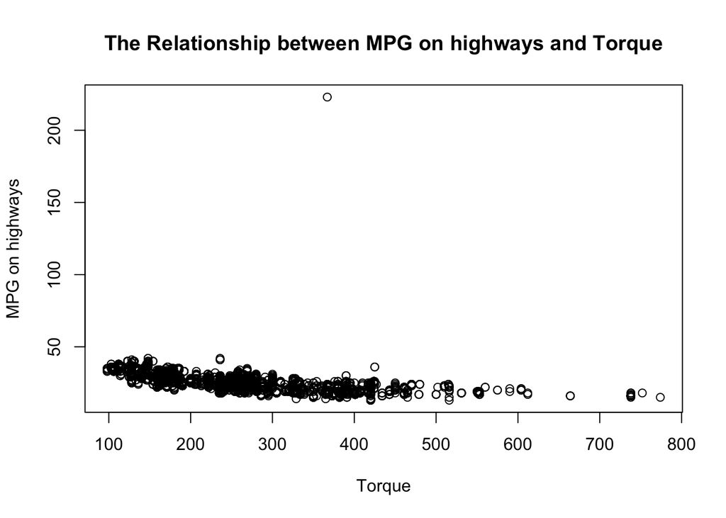

```r
attach(cars)
plot(torque, highway_mpg, main = "The Relationship between MPG on highways and Torque", xlab = "Torque", ylab = "MPG on highways")
```

```r
# Check the number of outlier whose highway_mpg is greater than 50
sum(highway_mpg > 50)
```

```
[1] 1
```

```r
highway_mpg[highway_mpg > 50]
```

```
[1] 223
```

```r
cars <- cars[cars$highway_mpg <= 50, ] # remove the outlier
```

=> Because there is only one car whose highway_mpg is greater than 50 as 223 MPG, restric the data to cars whose highway_mpg is leass than 50.

**[plot without transformation]**

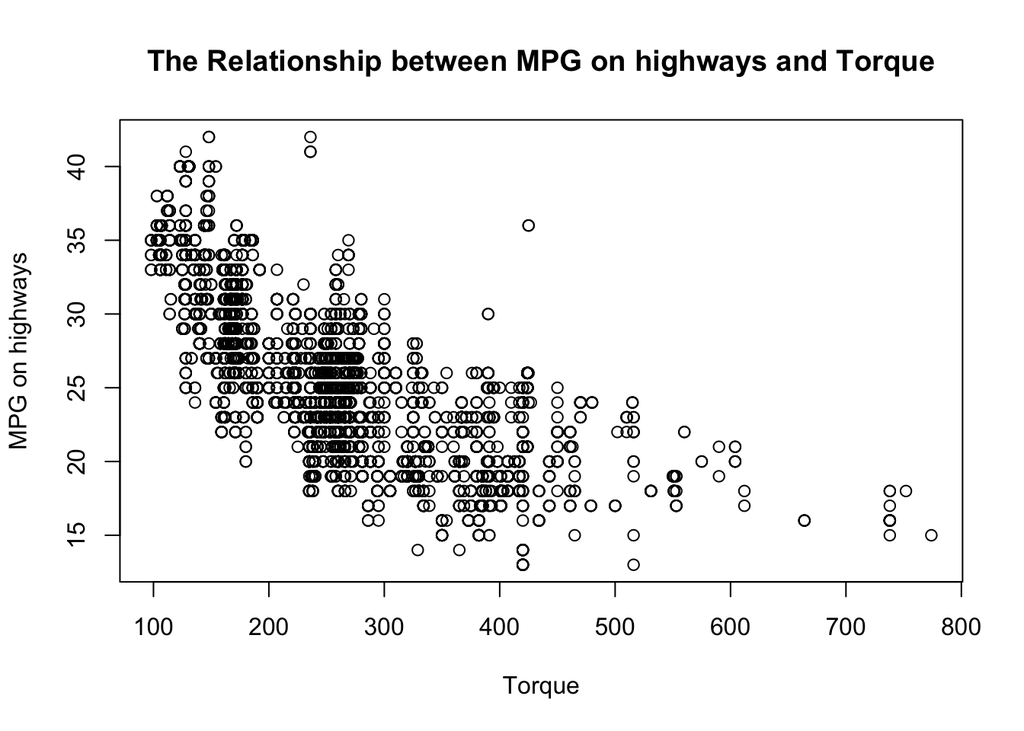

```r
plot(torque[highway_mpg <= 50], highway_mpg[highway_mpg <= 50], main = "The Relationship between MPG on highways and Torque", xlab = "Torque", ylab = "MPG on highways")
```

=> The relationship between MPG on highways and Torque is not linear. The MPG decreases exponentially with Torque. Therefore, a log transformation of Torque is helpful.

**[plot with logarithmic transformation on torque]**

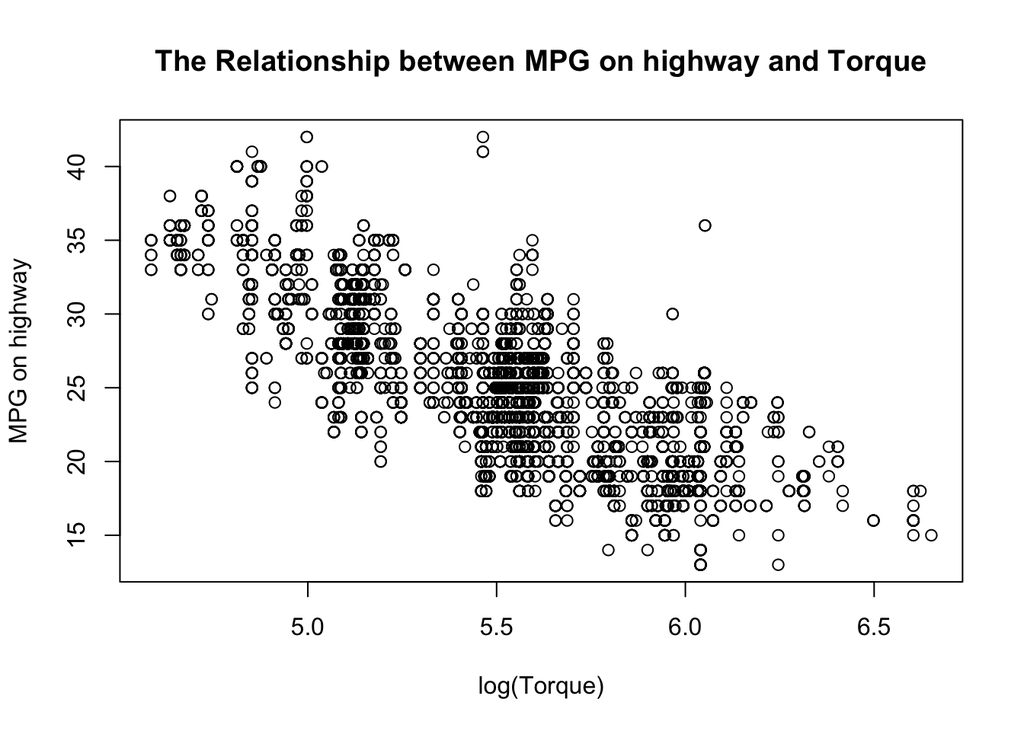

```r
plot(log(torque[highway_mpg <= 50]), highway_mpg[highway_mpg <= 50], main = "The Relationship between MPG on highway and Torque", xlab = "log(Torque)", ylab = "MPG on highway")
```

```r
cars$log_torque <- log(cars$torque) # add the transformation variable
```

**P2-d.** Fit a linear regression model predicting MPG on the highway

- There is negative linear relationshp between log(torque) and highway MPG
- The estimated coefficient for log_torque is -17.09. This means that a car with a log_torque that is 1 unit higher is expected to have a highway MPG that is 17.09 units lower than another car with the same height, length, width, horsepower and year, but a different log_torque.

```r
n1 <- sum(cars$height == 0) # the number of unknown height values
n2 <- sum(cars$length == 0) # the number of unknown length values
n3 <- sum(cars$width == 0) # the number of unknown width values
c(n1, n2, n3)
```

```
[1] 0 0 0
```

```r
cars$year <- as.factor(cars$year) # transform year into a categorical variable

# linear regression model predicting MPG on the highway
mod <- lm(highway_mpg~log_torque+height+length+width+hp+year, data = cars)
summary(mod)
```

```
Call:
lm(formula = highway_mpg ~ log_torque + height + length + width +
    hp + year, data = cars)

Residuals:
     Min       1Q   Median       3Q      Max
-12.3728  -2.1003  -0.3179   1.9704  20.5718

Coefficients:
              Estimate Std. Error t value Pr(>|t|)
(Intercept)  1.107e+02  1.567e+00  70.653  < 2e-16 ***
log_torque  -1.709e+01  3.287e-01 -52.005  < 2e-16 ***
height       6.359e-03  7.523e-04   8.453  < 2e-16 ***
length       8.248e-04  5.849e-04   1.410  0.15855
width       -2.439e-03  5.812e-04  -4.196 2.77e-05 ***
hp           2.817e-02  1.279e-03  22.034  < 2e-16 ***
year2010    -2.930e-01  4.480e-01  -0.654  0.51315
year2011     1.463e-01  4.473e-01   0.327  0.74368
year2012     1.324e+00  4.508e-01   2.938  0.00332 **
---
Signif. codes:  0 '***' 0.001 '**' 0.01 '*' 0.05 '.' 0.1 ' ' 1

Residual standard error: 3.047 on 4581 degrees of freedom
Multiple R-squared:  0.6675,    Adjusted R-squared:  0.6669
F-statistic:  1150 on 8 and 4581 DF,  p-value: < 2.2e-16
```

**P2-e.** Refit the model with an interaction terms and generate a plot,

**[linear regression model with an interation between torque and horsepower]**

```r
mod1 <- lm(highway_mpg~log_torque*hp+height+length+width+year, data = cars)
summary(mod1)
```

```
Call:
lm(formula = highway_mpg ~ log_torque * hp + height + length +
    width + year, data = cars)

Residuals:
     Min       1Q   Median       3Q      Max
-11.4962  -2.1112  -0.3202   1.9699  19.9065

Coefficients:
                Estimate Std. Error t value Pr(>|t|)
(Intercept)    1.154e+02  1.746e+00  66.109  < 2e-16 ***
log_torque    -1.762e+01  3.386e-01 -52.022  < 2e-16 ***
hp            -2.210e-02  8.396e-03  -2.632  0.00852 **
height         5.928e-03  7.528e-04   7.875 4.23e-15 ***
length         7.619e-04  5.827e-04   1.308  0.19108
width         -3.314e-03  5.968e-04  -5.554 2.96e-08 ***
year2010      -3.736e-01  4.465e-01  -0.837  0.40271
year2011       7.277e-02  4.457e-01   0.163  0.87032
year2012       1.281e+00  4.491e-01   2.851  0.00437 **
log_torque:hp  7.850e-03  1.296e-03   6.058 1.49e-09 ***
---
Signif. codes:  0 '***' 0.001 '**' 0.01 '*' 0.05 '.' 0.1 ' ' 1

Residual standard error: 3.035 on 4580 degrees of freedom
Multiple R-squared:  0.6701,    Adjusted R-squared:  0.6695
F-statistic:  1034 on 9 and 4580 DF,  p-value: < 2.2e-16
```

```r
table(year) # the number of 2011 is the largest among years.
```

```
year
2009 2010 2011 2012
  48 1633 1794 1116
```

```r
summary(cars$hp) # the distribution of horsepower (the mean of horsepower : 267.5)
```

```
   Min. 1st Qu.  Median    Mean 3rd Qu.    Max.
  100.0   185.0   263.0   267.5   317.0   638.0
```

```r
sd(cars$hp) # the standard error of horsepwoer (97.43795)
```

```
[1] 97.43795
```

```r
summary(cars$log_torque) # the distribution of log_torque (min : 4.585, max: 6.652)
```

```
   Min. 1st Qu.  Median    Mean 3rd Qu.    Max.
  4.585   5.176   5.549   5.517   5.804   6.652
```

**[interaction plot for the year 2011]**

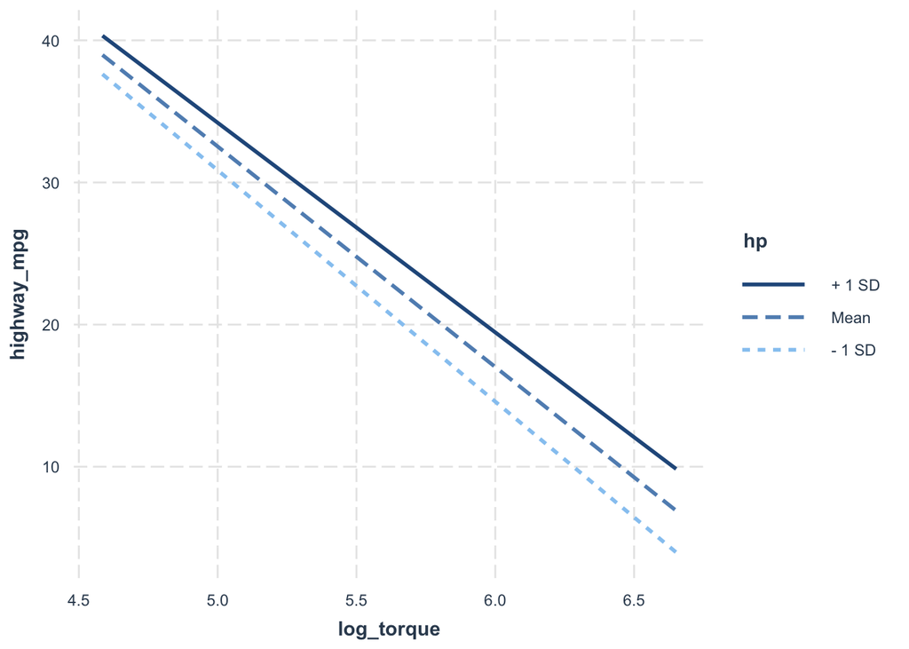

```r
library(interactions)
interact_plot(mod1, pred = log_torque, modx = hp, at = list(year = "2011"))
```

=> The highway MPG decreases less with larger log_torque as the horsepower increases, for log_torque values between 4.585 and 6.652.

**P2-f.** Calculate beta_hat from d. manually

```r
xmat <- model.matrix(mod, data = cars) # design matrix
beta_hat <- solve(t(xmat)%*%xmat)%*%t(xmat)%*%cars$highway_mpg # matrix algebra
beta_hat # beta_hat result
```

```
                     [,1]
(Intercept)  1.106967e+02
log_torque  -1.709203e+01
height       6.359467e-03
length       8.247831e-04
width       -2.438643e-03
hp           2.817440e-02
year2010    -2.930029e-01
year2011     1.462562e-01
year2012     1.324409e+00
```

```r
mod # result from lm function of d.
```

```
Call:
lm(formula = highway_mpg ~ log_torque + height + length + width +
    hp + year, data = cars)

Coefficients:
(Intercept)   log_torque       height       length        width           hp
  1.107e+02   -1.709e+01    6.359e-03    8.248e-04   -2.439e-03    2.817e-02
   year2010     year2011     year2012
 -2.930e-01    1.463e-01    1.324e+00
```